# If Ovechkin catches Gretzky’s goal record, will he be the best?

### Overview

[figure not shown]

This race for the all-time scorer title is all-over the sports media. If you want to read to study more about it click on the link [here.](https://www.cbssports.com/nhl/news/alex-ovechkin-scores-700th-goal-but-how-serious-is-his-pursuit-of-wayne-gretzkys-record/)

This project includes the following activities

- Calculate using standard math computation if Ovechkin can catch Gretzky
- Compare Ovechkin to Gretzky and the leading players
- Build a model that predicts the Ovechkin’s goals scored

### Setup

```python
import pandas as pd
import numpy as np
import matplotlib.pyplot as plt
import re
from bs4 import BeautifulSoup
import requests
import warnings
import sklearn
from sklearn.linear_model import LinearRegression
from sklearn.model_selection import train_test_split
import statsmodels.formula.api as stat
```

### Loading the Data

The data is loaded from the CSV which was obtained from the website QuantHockey at [www.quanthockey.com.](https://www.quanthockey.com)

```python
#read in csv
df = pd.read_csv("hockey_data.csv")
```

### Tidying the data

The tidying process was fairly simple. The column header is set to the first row and then the row is dropped.

```python
#set column headers
df.columns = df.iloc[0]
#drop first row as it contains column headers
df = df.drop(df.index[0])
df
```

|  | Rk | Name | Born | Pos | GP | G | A | P | PIM | +/- | ... | G/GP | A/GP | P/GP | SHOTS | SH% | HITS | BS | FOW | FOL | FO% |
| --- | --- | --- | --- | --- | --- | --- | --- | --- | --- | --- | --- | --- | --- | --- | --- | --- | --- | --- | --- | --- | --- |
| 1 | 1 | Alexander Ovechkin | 1985 | F | 1197 | 730 | 590 | 1320 | 731 | 75 | ... | 0.61 | 0.493 | 1.103 | 5727 | 12.8% | 3128 | 475 | 56 | 108 | 34.15% |
| 2 | 2 | Patrick Marleau | 1979 | F | 1779 | 566 | 631 | 1197 | 527 | -27 | ... | 0.318 | 0.355 | 0.673 | 4333 | 13.1% | 1157 | 406 | 6836 | 7584 | 47.41% |
| 3 | 3 | Sidney Crosby | 1987 | F | 1039 | 486 | 839 | 1325 | 699 | 183 | ... | 0.468 | 0.808 | 1.275 | 3331 | 14.6% | 892 | 502 | 11820 | 10867 | 52.10% |
| 4 | 4 | Eric Staal | 1984 | F | 1293 | 441 | 593 | 1034 | 828 | -77 | ... | 0.341 | 0.459 | 0.8 | 3935 | 11.2% | 897 | 484 | 9720 | 10431 | 48.24% |
| 5 | 5 | Steven Stamkos | 1990 | F | 841 | 439 | 427 | 866 | 515 | 48 | ... | 0.522 | 0.508 | 1.03 | 2589 | 17.0% | 910 | 358 | 5002 | 5062 | 49.70% |
| ... | ... | ... | ... | ... | ... | ... | ... | ... | ... | ... | ... | ... | ... | ... | ... | ... | ... | ... | ... | ... | ... |
| 196 | 196 | Zach Hyman | 1992 | F | 345 | 86 | 99 | 185 | 201 | 72 | ... | 0.249 | 0.287 | 0.536 | 706 | 12.2% | 480 | 189 | 285 | 367 | 43.71% |
| 197 | 197 | Conor Sheary | 1992 | F | 378 | 86 | 86 | 172 | 76 | 1 | ... | 0.228 | 0.228 | 0.455 | 684 | 12.6% | 154 | 134 | 28 | 39 | 41.79% |
| 198 | 198 | Marcus Foligno | 1991 | F | 604 | 86 | 123 | 209 | 540 | 11 | ... | 0.142 | 0.204 | 0.346 | 697 | 12.3% | 1707 | 359 | 283 | 319 | 47.01% |
| 199 | 199 | Kevin Shattenkirk | 1989 | D | 734 | 85 | 313 | 398 | 434 | 2 | ... | 0.116 | 0.426 | 0.542 | 1500 | 5.7% | 713 | 946 | 1 | 3 | 25.00% |
| 200 | 200 | Tyler Myers | 1990 | D | 755 | 85 | 219 | 304 | 566 | -7 | ... | 0.113 | 0.29 | 0.403 | 1278 | 6.7% | 896 | 1088 | 0 | 1 | 0.00% |

200 rows × 49 columns

### Calculate Projected Data for Goals and Points

First we need to calculate who in the NHL can catch Gretzky’s total career goals. I decided to do this using relatively simple method:

- Determine how many more season’s each play may play using 40 years old as the retirement age
- Calculate estimated goals to be scored in the future by multiplying the years remaining by 70 games played per season by each player’s average goals per game
- Add estimated goals to current goals scored and that will give the projected goals at the end of each player’s career

There are weaknesses in this simplification including

- A player may not play until they are 40
- A player may not score at the same rate as they age
- A player may not play only or at least 70 games per season

Explanation for calculations are in code comments.

```python
#Calculate Age
age = []
#current year (2021) - born year (i) = age
for i in df['Born']:
    age.append(2021 - int(i))

#create new column for age
df['Age'] = age
```

```python
#Playing Years Left
retire = []
#waynes age (40) - age = seasons til retire
for i in df['Age']:
    retire.append(40 - int(i))

#create new column for seasons left until retirement
df['Retire'] = retire
```

```python
#Total Estimated Goals Left in Career
games_left = []
#games per season * seasons til retire * goal/game played = est remaining goals
for i in df['Retire']:
    games_left.append(70*float(i))
df["raw_remaining_goals"] = games_left
games_left2 = []

#new column, remaining goals = (70*i in retire) * (g/gp)
df['Remaining Goals'] = df["raw_remaining_goals"] * df["G/GP"].astype(float)
```

```python
#Total Estimated Career Goals
games_left2 = []

#create new column for estimated career goals
#est career goals = remaining goals + goals
df['Est Career Goals'] = df["Remaining Goals"] + df["G"].astype(float)
```

```python
#Estimated Goals Away from Wayne Gretzky (894)
lst = []
#est career goals - Gretzky goals = est goals away from Gretzky
for i in df['Est Career Goals']:
    lst.append(i-894)

#new column for goals away from Gretzky
df['Goals Away Gretzky'] = lst
```

```python
#Total Estimated Points Left in Career
lst = []

#remaining points = 70 * seasons left * points/game
#new column for remaining career points
df['Remaining Points'] = df["raw_remaining_goals"] * df["P/GP"].astype(float)
```

```python
#Total Estimated Career Points
lst = []

#total est points = points + remaining points
#new column for total est career points
df['Total Est Points'] = df['P'].astype(int) + df['Remaining Points']
```

```python
#Estimated Points Away from Wayne Gretzky (2857)
lst = []

#total est points (i) - total Gretzky points (2857) = est points away from Gretzky
for i in df['Total Est Points']:
    lst.append(i - 2857)

#new column for estimated points from Gretzky
df['Points From Gretzky'] = lst
```

```python
data = df[['Rk', 'Name', 'Age', 'Retire', 'Remaining Goals', 'Est Career Goals', 'Goals Away Gretzky', 'Remaining Points', 'Total Est Points', 'Points From Gretzky']]
data
```

|  | Rk | Name | Age | Retire | Remaining Goals | Est Career Goals | Goals Away Gretzky | Remaining Points | Total Est Points | Points From Gretzky |
| --- | --- | --- | --- | --- | --- | --- | --- | --- | --- | --- |
| 1 | 1 | Alexander Ovechkin | 36 | 4 | 170.80 | 900.80 | 6.80 | 308.84 | 1628.84 | -1228.16 |
| 2 | 2 | Patrick Marleau | 42 | -2 | -44.52 | 521.48 | -372.52 | -94.22 | 1102.78 | -1754.22 |
| 3 | 3 | Sidney Crosby | 34 | 6 | 196.56 | 682.56 | -211.44 | 535.50 | 1860.50 | -996.50 |
| 4 | 4 | Eric Staal | 37 | 3 | 71.61 | 512.61 | -381.39 | 168.00 | 1202.00 | -1655.00 |
| 5 | 5 | Steven Stamkos | 31 | 9 | 328.86 | 767.86 | -126.14 | 648.90 | 1514.90 | -1342.10 |
| ... | ... | ... | ... | ... | ... | ... | ... | ... | ... | ... |
| 196 | 196 | Zach Hyman | 29 | 11 | 191.73 | 277.73 | -616.27 | 412.72 | 597.72 | -2259.28 |
| 197 | 197 | Conor Sheary | 29 | 11 | 175.56 | 261.56 | -632.44 | 350.35 | 522.35 | -2334.65 |
| 198 | 198 | Marcus Foligno | 30 | 10 | 99.40 | 185.40 | -708.60 | 242.20 | 451.20 | -2405.80 |
| 199 | 199 | Kevin Shattenkirk | 32 | 8 | 64.96 | 149.96 | -744.04 | 303.52 | 701.52 | -2155.48 |
| 200 | 200 | Tyler Myers | 31 | 9 | 71.19 | 156.19 | -737.81 | 253.89 | 557.89 | -2299.11 |

200 rows × 10 columns

Notice above that under the Column “Goals Away Gretzky” this number represents that Ovechkin would have 6.8 goals more the Gretzky after the next 4 seasons. This simple calculation shows that Ovechkin has a real chance if he stays healthy. Machine learning will be used later to also determine how many goals Ovechkin will have at the end of his career and therefore, will he catch Gretzky?

### We Need More Data to Compare the Two Stars

To find out the comparison between these hockey players, we need to analyze more data. For this we need to use additional data from the dataset that was loaded from QuantHockey. The focus this time is one performance statistics for the Top 200 players both active and retired.

Source of Data: QuantHockey at www.quanthockey.com

My analysis will be to use goals, points, gaming winning goals, and game winning points. These metrics are often used in Hockey to determine the best players. The “game winning” category shows what is possible during the clutch times when the team needs the stars to make their biggest impact.

Here is the data for Ovechkin

### Source of the Data

This data comes from Alex Ovechkin's espn statistics page.

```python
#Ovi ESPN Data
url = 'https://www.espn.com/nhl/player/stats/_/id/3101/alex-ovechkin'
r = requests.get(url)
soup = BeautifulSoup(r.text, 'html.parser')
```

### Scraping the Data

```python
#find html table
player_table = soup.find_all('table', class_ = 'tablehead')
player_table = player_table[0]

#empty list to put data into
table = []

#insert html table rows and columns into dataframe
rows = player_table.find_all('tr')
for row in rows:
    cols = row.find_all('td')
    if cols:
        cols = [e.text.strip() for e in cols]
        table.append([e for e in cols if e])
```

### Tidying the Data

The first row is set to the headers for each column. Then it is dropped along with a nonesense row and a total row at the end.

```python
#clean up table
resultsDF = pd.DataFrame(table)
resultsDF.columns = resultsDF.iloc[1]
resultsDF = resultsDF.drop(resultsDF.index[0])
resultsDF = resultsDF.drop(resultsDF.index[0])
resultsDF = resultsDF.drop(resultsDF.index[16])
resultsDF
```

### Here is the data for Ovechkin

| 1 | SEASON | TEAM | GP | G | A | PTS | +/- | PIM | SOG | % | PPG | PPA | SHG | SHA | GWG | GTG | TOI/G | PROD |
| --- | --- | --- | --- | --- | --- | --- | --- | --- | --- | --- | --- | --- | --- | --- | --- | --- | --- | --- |
| 2 | '05-'06 | WSH | 81 | 52 | 54 | 106 | 2 | 52 | 425 | 12.2 | 21 | 31 | 3 | 0 | 5 | -- | 21:37 | 16:31 |
| 3 | '06-'07 | WSH | 82 | 46 | 46 | 92 | -19 | 52 | 392 | 11.7 | 16 | 21 | 0 | 0 | 8 | -- | 21:18 | 18:59 |
| 4 | '07-'08 | WSH | 82 | 65 | 47 | 112 | 28 | 40 | 446 | 14.6 | 22 | 15 | 0 | 0 | 11 | -- | 23:07 | 16:55 |
| 5 | '08-'09 | WSH | 79 | 56 | 54 | 110 | 8 | 72 | 528 | 10.6 | 19 | 27 | 1 | 0 | 10 | -- | 22:59 | 16:30 |
| 6 | '09-'10 | WSH | 72 | 50 | 59 | 109 | 45 | 89 | 368 | 13.6 | 13 | 23 | 0 | 0 | 7 | -- | 21:48 | 14:24 |
| 7 | '10-'11 | WSH | 79 | 32 | 53 | 85 | 24 | 41 | 367 | 8.7 | 7 | 17 | 0 | 0 | 11 | -- | 21:22 | 19:51 |
| 8 | '11-'12 | WSH | 78 | 38 | 27 | 65 | -8 | 26 | 303 | 12.5 | 13 | 10 | 0 | 0 | 3 | -- | 19:48 | 23:46 |
| 9 | '12-'13 | WSH | 48 | 32 | 24 | 56 | 2 | 36 | 220 | 14.5 | 16 | 11 | 0 | 0 | 4 | -- | 20:53 | 17:54 |
| 10 | '13-'14 | WSH | 78 | 51 | 28 | 79 | -35 | 48 | 386 | 13.2 | 24 | 15 | 0 | 1 | 10 | -- | 20:33 | 20:17 |
| 11 | '14-'15 | WSH | 81 | 53 | 28 | 81 | 10 | 58 | 395 | 13.4 | 25 | 9 | 0 | 0 | 11 | -- | 20:20 | 20:20 |
| 12 | '15-'16 | WSH | 79 | 50 | 21 | 71 | 21 | 53 | 398 | 12.6 | 19 | 5 | 0 | 0 | 8 | -- | 20:19 | 22:36 |
| 13 | '16-'17 | WSH | 82 | 33 | 36 | 69 | 6 | 50 | 313 | 10.5 | 17 | 9 | 0 | 0 | 7 | -- | 18:22 | 21:50 |
| 14 | '17-'18 | WSH | 82 | 49 | 38 | 87 | 3 | 32 | 355 | 13.8 | 17 | 14 | 0 | 0 | 7 | -- | 20:09 | 18:59 |
| 15 | '18-'19 | WSH | 81 | 51 | 38 | 89 | 7 | 40 | 338 | 15.1 | 18 | 10 | 0 | 0 | 5 | -- | 20:55 | 19:02 |
| 16 | '19-'20 | WSH | 68 | 48 | 19 | 67 | -12 | 30 | 311 | 15.4 | 13 | 5 | 0 | 0 | 3 | -- | 20:40 | 20:58 |
| 17 | '20-'21 | WSH | 45 | 24 | 18 | 42 | -7 | 12 | 182 | 13.2 | 9 | 8 | 0 | 0 | 6 | -- | 19:30 | 20:54 |

### Source of the Data

This data comes from Wayne Gretzky's espn statistics page.

```python
#Gretzky ESPN Data
url = 'https://www.espn.com/nhl/player/stats/_/id/4128/wayne-gretzky'
r = requests.get(url)
soup = BeautifulSoup(r.text, 'html.parser')
```

### Scraping the Data

```python
#find html table
player_table = soup.find_all('table', class_ = 'tablehead')
player_table = player_table[0]

#empty list to put data into
table = []

#insert html table rows and columns into dataframe
rows = player_table.find_all('tr')
for row in rows:
    cols = row.find_all('td')
    if cols:
        cols = [e.text.strip() for e in cols]
        table.append([e for e in cols if e])
```

### Tidying the Data

The first row is set to the headers for each column. Then it is dropped along with a nonesense row and a total row at the end.

```python
resultsDF2 = pd.DataFrame(table)
resultsDF2.columns = resultsDF2.iloc[1]
resultsDF2 = resultsDF2.drop(resultsDF2.index[0])
resultsDF2 = resultsDF2.drop(resultsDF2.index[0])
resultsDF2 = resultsDF2.drop(resultsDF2.index[21])
resultsDF2
```

### Here is the data for Gretzky

| 1 | SEASON | TEAM | GP | G | A | PTS | +/- | PIM | SOG | % | PPG | PPA | SHG | SHA | GWG | GTG | TOI/G | PROD |
| --- | --- | --- | --- | --- | --- | --- | --- | --- | --- | --- | --- | --- | --- | --- | --- | --- | --- | --- |
| 2 | '79-'80 | EDM | 79 | 51 | 86 | 137 | 15 | 21 | 284 | 18.0 | 13 | 22 | 1 | 1 | 6 | 4 | 0:00 | 0:00 |
| 3 | '80-'81 | EDM | 80 | 55 | 109 | 164 | 41 | 28 | 261 | 21.1 | 15 | 38 | 4 | 3 | 3 | 2 | 0:00 | 0:00 |
| 4 | '81-'82 | EDM | 80 | 92 | 120 | 212 | 81 | 26 | 369 | 24.9 | 18 | 39 | 6 | 2 | 12 | 3 | 0:00 | 0:00 |
| 5 | '82-'83 | EDM | 80 | 71 | 125 | 196 | 60 | 59 | 348 | 20.4 | 18 | 36 | 6 | 4 | 9 | 0 | 0:00 | 0:00 |
| 6 | '83-'84 | EDM | 74 | 87 | 118 | 205 | 76 | 39 | 324 | 26.9 | 20 | 27 | 12 | 11 | 11 | 0 | 0:00 | 0:00 |
| 7 | '84-'85 | EDM | 80 | 73 | 135 | 208 | 98 | 52 | 358 | 20.4 | 8 | 36 | 11 | 7 | 7 | 2 | 0:00 | 0:00 |
| 8 | '85-'86 | EDM | 80 | 52 | 163 | 215 | 71 | 46 | 350 | 14.9 | 11 | 43 | 3 | 15 | 6 | 1 | 0:00 | 0:00 |
| 9 | '86-'87 | EDM | 79 | 62 | 121 | 183 | 70 | 28 | 288 | 21.5 | 13 | 33 | 7 | 6 | 4 | 0 | 0:00 | 0:00 |
| 10 | '87-'88 | EDM | 64 | 40 | 109 | 149 | 39 | 24 | 211 | 19.0 | 9 | 40 | 5 | 4 | 3 | 0 | 0:00 | 0:00 |
| 11 | '88-'89 | LA | 78 | 54 | 114 | 168 | 15 | 26 | 303 | 17.8 | 11 | 42 | 5 | 10 | 5 | 2 | 0:00 | 0:00 |
| 12 | '89-'90 | LA | 73 | 40 | 102 | 142 | 8 | 42 | 236 | 16.9 | 10 | 30 | 4 | 2 | 4 | 1 | 0:00 | 0:00 |
| 13 | '90-'91 | LA | 78 | 41 | 122 | 163 | 30 | 16 | 212 | 19.3 | 8 | 51 | 0 | 1 | 5 | 2 | 0:00 | 0:00 |
| 14 | '91-'92 | LA | 74 | 31 | 90 | 121 | -12 | 34 | 215 | 14.4 | 12 | 42 | 2 | 2 | 2 | 1 | 0:00 | 0:00 |
| 15 | '92-'93 | LA | 45 | 16 | 49 | 65 | 6 | 6 | 141 | 11.3 | 0 | 24 | 2 | 1 | 1 | 0 | 0:00 | 0:00 |
| 16 | '93-'94 | LA | 81 | 38 | 92 | 130 | -25 | 20 | 233 | 16.3 | 14 | 47 | 4 | 3 | 0 | 1 | 0:00 | 0:00 |
| 17 | '94-'95 | LA | 48 | 11 | 37 | 48 | -20 | 6 | 142 | 7.7 | 3 | 19 | 0 | 3 | 1 | 0 | 0:00 | 0:00 |
| 18 | '95-'96 | LA | 62 | 15 | 66 | 81 | -7 | 32 | 144 | 10.4 | 5 | 32 | 0 | 0 | 2 | 1 | 0:00 | 0:00 |
| 19 | '95-'96 | STL | 18 | 8 | 13 | 21 | -6 | 2 | 51 | 15.7 | 1 | 9 | 1 | 0 | 1 | 0 | 0:00 | 0:00 |
| 20 | '96-'97 | NYR | 82 | 25 | 72 | 97 | 12 | 28 | 286 | 8.7 | 6 | 25 | 0 | 1 | 2 | 1 | 0:00 | 0:00 |
| 21 | '97-'98 | NYR | 82 | 23 | 67 | 90 | -11 | 28 | 201 | 11.4 | 6 | 24 | 0 | 0 | 4 | 2 | 0:00 | 0:00 |
| 22 | '98-'99 | NYR | 70 | 9 | 53 | 62 | -23 | 14 | 132 | 6.8 | 3 | 27 | 0 | 0 | 3 | 1 | 0:00 | 0:00 |

### Exploratory Data Analysis – Ovechkin vs Gretzky

First let’s describe what each header item means:

- Season: Year player played hocket
- Team: Player’s team
- GP Games played: Total games played per season
- G Goals: Goals scored per season
- PTS Points: Points scored per season, point = goals + assists
- SOG Shots on Goal: Total shots on goal per season
- % Shooting Percent: Goals divided by shots on goal, goal = shot
- GWG Game Winning Goals: Goals scored by player that won the game for player’s team
- GWP Game Winning Points: Pointts scored by player that won the game for player’s team

Now let’s perform linear regression on both Ovechkin’s and Gretzky’s goals to see if correlation between goals and games played. The reason this is important is that Ovechkin is 36 so he has a limited number of games left in his career, so this correlation is important.

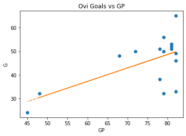

[figure not shown]

```python
#Convert columns to ints
resultsDF['GP'] = resultsDF['GP'].astype(int)
resultsDF['G'] = resultsDF['G'].astype(int)
resultsDF2['GP'] = resultsDF2['GP'].astype(int)
resultsDF2['G'] = resultsDF2['G'].astype(int)

#Ovi Graph

#axis values
x_axis = resultsDF['GP'].values
y_axis = resultsDF['G'].values

#plot title
plt.title("Ovi Goals vs GP")

#insert axis values
plt.plot(x_axis, y_axis, '8')

#reshape for linear regression
x_axis = np.array(resultsDF["GP"]).reshape(-1, 1)
y_axis = np.array(resultsDF["G"]).reshape(-1, 1)

#apply linear regression to curve
reg = LinearRegression().fit(x_axis, y_axis)
plt.plot(x_axis, reg.intercept_ + reg.coef_ * x_axis, '--')

#label x and y values
plt.xlabel('GP')
plt.ylabel('G')

#display plot
plt.show()

#Wayne Graph
x_axis2 = resultsDF2['GP'].values
y_axis2 = resultsDF2['G'].values

#plot title
plt.title("Wayne Goals vs GP")

#insert axis values
plt.plot(x_axis2, y_axis2, '8')

#reshape for linear regression
x_axis2 = np.array(resultsDF2["GP"]).reshape(-1, 1)
y_axis2 = np.array(resultsDF2["G"]).reshape(-1, 1)

#apply linear regression to curve
reg2 = LinearRegression().fit(x_axis, y_axis)
plt.plot(x_axis2, reg2.intercept_ + reg2.coef_ * x_axis2, '--')

#label x and y values
plt.xlabel('GP')
plt.ylabel('G')

#display plot
plt.show()
```

```python
#Ovi Linear Regression Output
plot_output = stat.ols(formula = "G ~ GP", data = resultsDF).fit()
print(plot_output.summary())
```

```
                            OLS Regression Results
==============================================================================
Dep. Variable:                      G   R-squared:                       0.383
Model:                            OLS   Adj. R-squared:                  0.339
Method:                 Least Squares   F-statistic:                     8.681
Date:                Mon, 17 May 2021   Prob (F-statistic):             0.0106
Time:                        01:15:30   Log-Likelihood:                -56.391
No. Observations:                  16   AIC:                             116.8
Df Residuals:                      14   BIC:                             118.3
Df Model:                           1
Covariance Type:            nonrobust
==============================================================================
                 coef    std err          t      P>|t|      [0.025      0.975]
------------------------------------------------------------------------------
Intercept      2.9562     14.647      0.202      0.843     -28.459      34.371
GP             0.5703      0.194      2.946      0.011       0.155       0.986
==============================================================================
Omnibus:                        1.733   Durbin-Watson:                   1.733
Prob(Omnibus):                  0.420   Jarque-Bera (JB):                0.886
Skew:                          -0.576   Prob(JB):                        0.642
Kurtosis:                       2.948   Cond. No.                         505.
==============================================================================

Notes:
[1] Standard Errors assume that the covariance matrix of the errors is correctly specified.
```

```python
#Gretzky Linear Regression Output
plot_output = stat.ols(formula = "G ~ GP", data = resultsDF2).fit()
print(plot_output.summary())
```

```
                            OLS Regression Results
==============================================================================
Dep. Variable:                      G   R-squared:                       0.334
Model:                            OLS   Adj. R-squared:                  0.298
Method:                 Least Squares   F-statistic:                     9.509
Date:                Mon, 17 May 2021   Prob (F-statistic):            0.00611
Time:                        01:15:30   Log-Likelihood:                -92.722
No. Observations:                  21   AIC:                             189.4
Df Residuals:                      19   BIC:                             191.5
Df Model:                           1
Covariance Type:            nonrobust
==============================================================================
                 coef    std err          t      P>|t|      [0.025      0.975]
------------------------------------------------------------------------------
Intercept    -21.5150     21.284     -1.011      0.325     -66.063      23.033
GP             0.9051      0.294      3.084      0.006       0.291       1.519
==============================================================================
Omnibus:                        0.822   Durbin-Watson:                   0.775
Prob(Omnibus):                  0.663   Jarque-Bera (JB):                0.628
Skew:                           0.394   Prob(JB):                        0.730
Kurtosis:                       2.691   Cond. No.                         336.
==============================================================================

Notes:
[1] Standard Errors assume that the covariance matrix of the errors is correctly specified.
```

### Linear Regression Analysis of Ovechkin and Gretzky Data

I found an interesting article about the R-squared values and what low values and high values represent based on the data. You can read it [here.](https://statisticsbyjim.com/regression/interpret-r-squared-regression/)

### More Exploration and Analysis

The next analysis is on the all hockey players both active and retired. The idea is to find some linear correlation because the next step is to use SciKit Learn with Linear Regression to predict Ovechkin’s goals.

### Loading the Data

The data is loaded from the CSV which was obtained from the website QuantHockey at www.quanthockey.com

```python
#read in csv of all top players (no longer just active)
df2 = pd.read_csv("hockey_data2.csv")
df2.columns = df2.iloc[0]
df2 = df2.drop(df2.index[0])
```

### Tidying the data

Players with foreign letters in their name are adjusted. One player played before they kept track of shots therefore set his value to a similar data point to others at his goals.

```python
#Tidying Names with foreign characters
df2.loc[3,'Name'] = 'Jaromir Jagr'
df2.loc[196,'Name'] = 'Petr Klima'
df2.loc[12,'Name'] = 'Teemu Selanne'

#Pre Shot Count Era
df2.loc[180,'SHOTS'] = '2500'
```

```python
#df.head()
df2 = df2[['Rk', 'Name', 'G', 'A', 'P', 'GWP', 'GWG', 'GP', 'SHOTS']]
df2
```

|  | Rk | Name | G | A | P | GWP | GWG | GP | SHOTS |
| --- | --- | --- | --- | --- | --- | --- | --- | --- | --- |
| 1 | 1 | Wayne Gretzky | 894 | 1963 | 2857 | 330 | 91 | 1487 | 5083 |
| 2 | 2 | Gordie Howe | 801 | 1049 | 1850 | 280 | 120 | 1767 | 3803 |
| 3 | 3 | Jaromir Jagr | 766 | 1155 | 1921 | 315 | 135 | 1733 | 5637 |
| 4 | 4 | Brett Hull | 741 | 650 | 1391 | 219 | 110 | 1269 | 4876 |
| 5 | 5 | Marcel Dionne | 731 | 1040 | 1771 | 200 | 73 | 1348 | 5363 |
| ... | ... | ... | ... | ... | ... | ... | ... | ... | ... |
| 196 | 196 | Petr Klima | 313 | 260 | 573 | 65 | 36 | 786 | 1852 |
| 197 | 197 | Don Lever | 313 | 367 | 680 | 66 | 23 | 1020 | 2156 |
| 198 | 198 | Jamie Benn | 311 | 412 | 723 | 124 | 49 | 866 | 2369 |
| 199 | 199 | Petr Nedved | 310 | 407 | 717 | 93 | 39 | 982 | 2207 |
| 200 | 200 | Denis Potvin | 310 | 742 | 1052 | 132 | 44 | 1060 | 3050 |

200 rows × 9 columns

This plot below of Goals vs. Games Played has some potential as there is linearity.

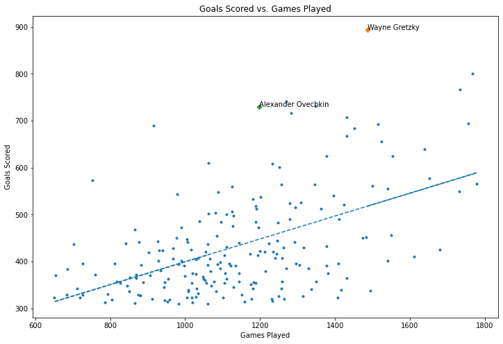

```python
#set plot size
plt.subplots(figsize = (12,8))

#set data type to int
df2['GP'] = df2['GP'].astype(int)
df2['G'] = df2['G'].astype(int)

#set axis values
plt.scatter(marker = ".", x = df2["GP"].astype(int), y = df2["G"].astype(int))

#mark Ovi and Gretzky
for x in df2.itertuples():
    name = x[2]
    goals = x[3]
    games_played = x[8]
    if(name == "Wayne Gretzky" or name == "Alexander Ovechkin"):
        plt.scatter(marker = "P", x = x[8], y = x[3])
        plt.annotate(x[2], (x[8], x[3]))

games_played = np.array(df2["GP"]).reshape(-1, 1)
goals = np.array(df2["G"]).reshape(-1, 1)

#create plot and regression
reg = LinearRegression().fit(games_played, goals)
plt.plot(games_played, reg.intercept_ + reg.coef_ * games_played, '--')

#label axis
x = "Games Played"
y = "Goals Scored"
#insert labels
plt.xlabel(x)
plt.ylabel(y)
#plot title
plt.title(y + " " + "vs." + " " + x)
#display plot
plt.show()
```

This plot below of Points vs. Games Played has linearity. Remember points are calculated by adding goals and assists.

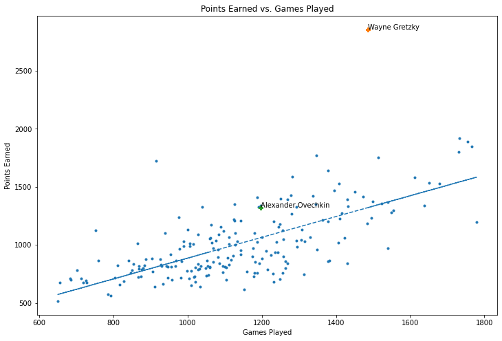

```python
#plot size
plt.subplots(figsize = (12,8))

#set data type to int
df2['P'] = df2['P'].astype(int)

#set axis values
plt.scatter(marker = ".", x = df2["GP"], y = df2["P"])

#mark Ovi and Gretzky
for x in df2.itertuples():
    name = x[2]
    points = x[5]
    games_played = x[8]
    if(name == "Wayne Gretzky" or name == "Alexander Ovechkin"):
        plt.scatter(marker = "P", x = x[8], y = x[5])
        plt.annotate(x[2], (x[8], x[5]))

games_played = np.array(df2["GP"]).reshape(-1, 1)
points = np.array(df2["P"]).reshape(-1, 1)

#create plot and regression
reg = LinearRegression().fit(games_played, points)
plt.plot(games_played, reg.intercept_ + reg.coef_ * games_played, '--')

#label axis
x = "Games Played"
y = "Points Earned"
#insert labels
plt.xlabel(x)
plt.ylabel(y)
#plot title
plt.title(y + " " + "vs." + " " + x)
#display plot
plt.show()
```

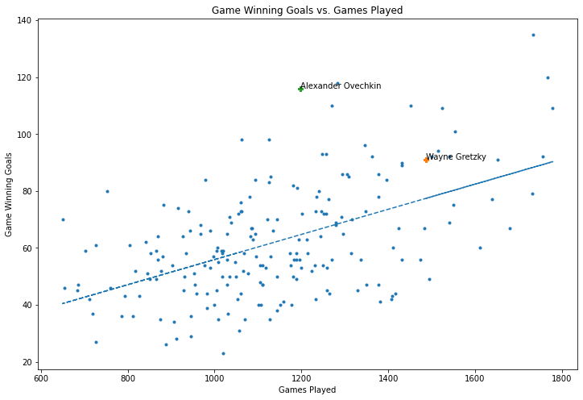

```python
#plot size
plt.subplots(figsize = (12,8))

#set data type to int
df2['GWG'] = df2['GWG'].astype(int)

#set axis values
plt.scatter(marker = ".", x = df2["GP"], y = df2["GWG"])

#mark Ovi and Gretzky
for x in df2.itertuples():
    name = x[2]
    winning_goals = x[7]
    games_played = x[8]
    if(name == "Wayne Gretzky" or name == "Alexander Ovechkin"):
        plt.scatter(marker = "P", x = x[8], y = x[7])
        plt.annotate(x[2], (x[8], x[7]))

games_played = np.array(df2["GP"]).reshape(-1, 1)
winning_goals = np.array(df2["GWG"]).reshape(-1, 1)

#create plot and regression
reg = LinearRegression().fit(games_played, winning_goals)
plt.plot(games_played, reg.intercept_ + reg.coef_ * games_played, '--')

#label axis
x = "Games Played"
y = "Game Winning Goals"
#insert labels
plt.xlabel(x)
plt.ylabel(y)
#plot title
plt.title(y + " " + "vs." + " " + x)
#display plot
plt.show()
```

This plot below of Game Winning Points vs. Games Played has linearity, but still may not help with determining goals.

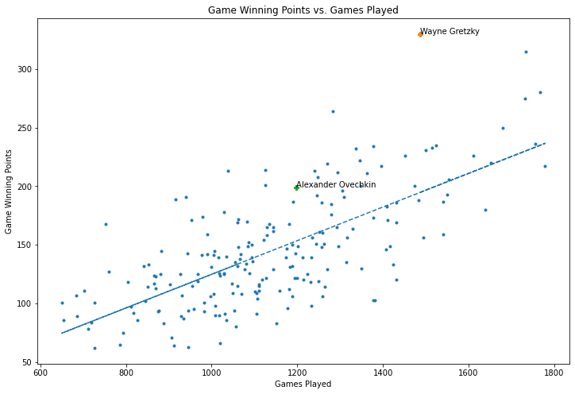

```python
#plot size
plt.subplots(figsize = (12,8))

#set data type to int
df2['GWP'] = df2['GWP'].astype(int)

#set axis values
plt.scatter(marker = ".", x = df2["GP"], y = df2["GWP"])

#mark Ovi and Gretzky
for x in df2.itertuples():
    name = x[2]
    winning_points = x[6]
    games_played = x[8]
    if(name == "Wayne Gretzky" or name == "Alexander Ovechkin"):
        plt.scatter(marker = "P", x = x[8], y = x[6])
        plt.annotate(x[2], (x[8], x[6]))

games_played = np.array(df2["GP"]).reshape(-1, 1)
winning_points = np.array(df2["GWP"]).reshape(-1, 1)

#create plot and regression
reg = LinearRegression().fit(games_played, winning_points)
plt.plot(games_played, reg.intercept_ + reg.coef_ * games_played, '--')

#label axis
x = "Games Played"
y = "Game Winning Points"
#insert labels
plt.xlabel(x)
plt.ylabel(y)
#plot title
plt.title(y + " " + "vs." + " " + x)
#display plot
plt.show()
```

### Let’s Try to Find If Statistics Really Impact Goals

Although some of the graphs show some linear correlation, I want to keep searching for a statistical analysis that may show this more clearly. There has been much debate for years about what hockey stats really matter in terms of naming the greatest player or most prolific goal scorer. Currently, tthe trend in all sports is saturation of data analysis and identification of trends from this analysis to better coach teams and select players. Recently NHL data analysts have been narrowing their focus to shots, not necessarily goals. The reason is that the variation in shooting percentage of star players is not significant. In fact there have been many data science papers written on the debate relationship between shots, goals, and the best players. So here is some analysis of the relationship between shots and goals. Why is the shots the most significant measure in a players performance. Well, hockey experts say that it is because shooting percentage (goals made per shots taken) variation is small among all players. Therefore, the best chance to increase the players goals made is to increase the shots taken. If you are interested in understanding more about this discussion on NHL goals, click here.

This plot below of Goals vs. Shots has some linearity.

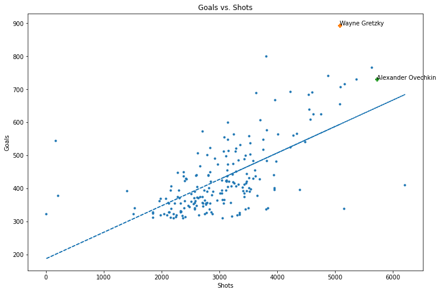

```python
#plot size
plt.subplots(figsize = (12,8))

#set axis values
plt.scatter(marker = ".", x = df2["SHOTS"], y = df2["G"])

#mark Ovi and Gretzky
for x in df2.itertuples():
    name = x[2]
    goals = x[3]
    shots = x[9]
    if(name == "Wayne Gretzky" or name == "Alexander Ovechkin"):
        plt.scatter(marker = "P", x = x[9], y = x[3])
        plt.annotate(x[2], (x[9], x[3]))

shots = np.array(df2["SHOTS"]).reshape(-1, 1)
goals = np.array(df2["G"]).reshape(-1, 1)

#create plot and regression
reg = LinearRegression().fit(shots, goals)
plt.plot(shots, reg.intercept_ + reg.coef_ * shots, '--')

#label axis
x = "Shots"
y = "Goals"
#insert labels
plt.xlabel(x)
plt.ylabel(y)
#plot title
plt.title(y + " " + "vs." + " " + x)
#display plot
plt.show()
```

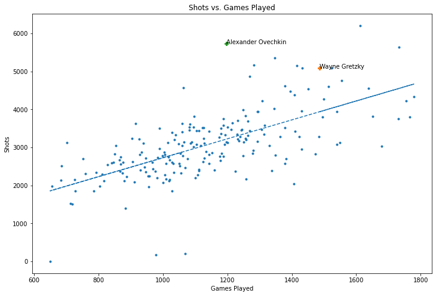

```python
#plot size
plt.subplots(figsize = (12,8))

#set axis values
plt.scatter(marker = ".", x = df2["GP"], y = df2["SHOTS"])

#mark Ovi and Gretzky
for x in df2.itertuples():
    name = x[2]
    games_played = x[8]
    shots = x[9]
    if(name == "Wayne Gretzky" or name == "Alexander Ovechkin"):
        plt.scatter(marker = "P", x = x[8], y = x[9])
        plt.annotate(x[2], (x[8], x[9]))

shots = np.array(df2["GP"]).reshape(-1, 1)
goals = np.array(df2["SHOTS"]).reshape(-1, 1)

#create plot and regression
reg = LinearRegression().fit(shots, goals)
plt.plot(shots, reg.intercept_ + reg.coef_ * shots, '--')

#label axis
x = "Games Played"
y = "Shots"
#insert labels
plt.xlabel(x)
plt.ylabel(y)
#plot title
plt.title(y + " " + "vs." + " " + x)
#display plot
plt.show()
```

### Predicting Goals with Machine Learning

If you know even the slightest information about hockey you will know that scoring goals can happen for many reasons – skill of the player, luck of the puck being tipped, and goals caused by pulling the goalie at the end of the game. So trying to predict goals can be very difficult. If fact the experts have created sophisticated prediction models that use parameters that create an expected goals data point for every play in every game. For this project, I will make two attempts at the model. Both using two variable linear regression, but with different variables to see if the prediction and model accuracy is better when comparing models.

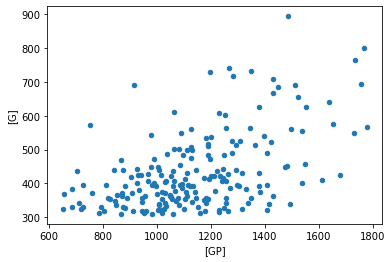

```python
#Machine Learning
df2.plot(kind = 'scatter', x = ['GP'], y = ['G'])
plt.show()
```

### Model 1: Use Games Played to Predict Goals

The first model is trained and tested using Games Played to predict Goals.

### Test Training

```python
#Train
X_train, X_test, y_train, y_test = train_test_split(df2.GP, df2.G)
```

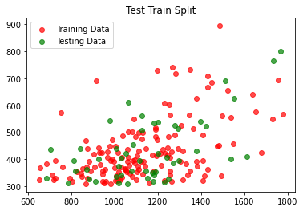

```python
#Test training on plot
plt.scatter(X_train, y_train, label = 'Training Data', color = 'r', alpha = .7)
plt.scatter(X_test, y_test, label = 'Testing Data', color = 'g', alpha = .7)
plt.legend()
plt.title('Test Train Split')
plt.show()
```

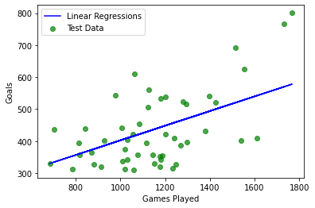

```python
LR = LinearRegression()
LR.fit(X_train.values.reshape(-1, 1), y_train.values)

#Predict on test data
prediction = LR.predict(X_test.values.reshape(-1,1))

#plot prediction line
plt.plot(X_test, prediction,  label = 'Linear Regressions', color = 'b')
plt.scatter(X_test, y_test, label = 'Test Data', color = 'g', alpha =.7)
plt.legend()
#label axis
plt.xlabel("Games Played")
plt.ylabel("Goals")
plt.show()
```

```python
#Prediction of how many goals will be scored at 2000 games played
LR.predict(np.array([[2000]]))[0]
```

```
631.2800077262814
```

```python
#Accuracy
LR.score(X_test.values.reshape(-1, 1), y_test.values)
```

```
0.34217544883695883
```

### Model 2: Use Ovechkin Minutes Played to Predict Goals

```python
#read in csv
dfOvi = pd.read_csv("Ovi-Every-10-Games-Data.csv")

#set column headers
#dfOvi.columns = df.iloc[0]

#drop first row as it contain
#df = df.drop(df.index[0])

dfOvi
```

|  | Year | Goals | Shots | min_played |
| --- | --- | --- | --- | --- |
| 0 | 2020 | 5.0 | 39.0 | 208.41 |
| 1 | 2020 | 2.0 | 41.0 | 197.42 |
| 2 | 2020 | 8.0 | 46.0 | 210.24 |
| 3 | 2020 | 7.0 | 35.0 | 186.80 |
| 4 | 2020 | 4.0 | 46.0 | 170.20 |
| ... | ... | ... | ... | ... |
| 81 | 2011 | 6.0 | 36.0 | 205.27 |
| 82 | 2011 | 4.0 | 46.0 | 200.33 |
| 83 | 2011 | 7.0 | 45.0 | 191.42 |
| 84 | 2011 | 6.0 | 38.0 | 216.28 |
| 85 | 2011 | 3.0 | 37.0 | 209.76 |

86 rows × 4 columns

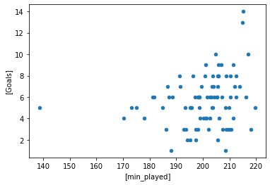

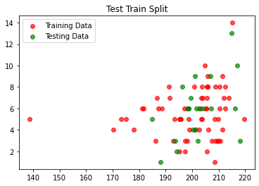

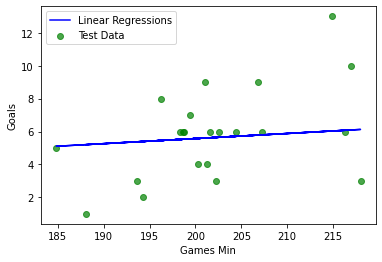

```python
#Machine Learning
dfOvi.plot(kind = 'scatter', x = ['min_played'], y = ['Goals'])
plt.show()

#Train
X_train, X_test, y_train, y_test = train_test_split(dfOvi.min_played, dfOvi.Goals)

#Test training on plot
plt.scatter(X_train, y_train, label = 'Training Data', color = 'r', alpha = .7)
plt.scatter(X_test, y_test, label = 'Testing Data', color = 'g', alpha = .7)
plt.legend()
plt.title('Test Train Split')
plt.show()

LR = LinearRegression()
LR.fit(X_train.values.reshape(-1, 1), y_train.values)

#Predict on test data
prediction = LR.predict(X_test.values.reshape(-1,1))

#plot prediction line
plt.plot(X_test, prediction,  label = 'Linear Regressions', color = 'b')
plt.scatter(X_test, y_test, label = 'Test Data', color = 'g', alpha =.7)
plt.legend()

#label axis
plt.xlabel("Games Min")
plt.ylabel("Goals")
plt.show()
```

```python
#Prediction of how many goals Ovi will score by retirement
LR.predict(np.array([[22800]]))[0]
```

```
702.1306290515016
```

### Conclusion: So Will Ovechkin Catch Gretzky?

The goal of this project was to try to determine if Alex Ovechkin can catch Wayne Gretzky to become the highest goal scorer in NHL history. At the beginning of the project I used simple math with goals per game assumptions to determine that he could catch Wayne Gretzky after 4 seasons. I analyzed the plots of games played for the Top 200 stars, then specifically for Ovechkin and Gretzky. These were analyzed using linear regression and although their R-squared values are low they still are in the range for typical human related results using linear regression. Then I tried to find additional data correlations that could help is predicting Ovechkin’s career goals. I plot shots, game winning shots, points, game winning point, and playing time – all in an effort to look for correlation. Well research shows that is difficult to find statistics that predict goals scored. Even so, I ran machine learning regression models and found the results for goals predicted were less than the original simple math. My research on hockey statistics shows that arguably shots of goal is the best predictor to goals but if we could predict that for the rest of Ovechkin’s career then that would be too simple. Even though the models predicted less goals than necessary to catch Gretzky, I think Ovechkin really will become the NHL career goals leader by the time he retires.